# PSDV assignment 3

```python
import pandas as pd
import numpy as np
import matplotlib.pyplot as plt
import seaborn as sns
```

```python
apdata = pd.read_csv(r"C:\Users\ujass\Downloads\Data.csv")   #CPCB Air Pollution Data
apdata.head()
```

|  | Timestamp | station | PM2.5 | PM10 | address | city | latitude | longitude | state |
| --- | --- | --- | --- | --- | --- | --- | --- | --- | --- |
| 0 | 2017-01-01 | 32Bungalows, Bhilai - CECB | NaN | NaN | Bhilai RO Office, 5, 32 Bungalows, Bhilai, Dis... | Bhilai | 21.194815 | 81.314770 | Chhattisgarh |
| 1 | 2017-01-01 | AIIMS, Raipur - CECB | NaN | NaN | All India Institute Of Medical Science, Gate N... | Raipur | 21.258815 | 81.578979 | Chhattisgarh |
| 2 | 2017-01-01 | Adarsh Nagar, Jaipur - RSPCB | NaN | NaN | Psychiatric Centre, Janta Colony, Govind Marg,... | Jaipur | 26.902909 | 75.836858 | Rajasthan |
| 3 | 2017-01-01 | Airoli, Navi Mumbai - MPCB | NaN | 54.743723 | NaN | Navi Mumbai | 19.149400 | 72.998600 | Maharashtra |
| 4 | 2017-01-01 | Airport Area, Indore - IMC | NaN | NaN | NaN | NaN | NaN | NaN | NaN |

```python
fundata = pd.read_csv(r"C:\Users\ujass\Downloads\NCAP_funding.csv")   #NCAP funding for cities
fundata.head()
```

|  | S. No. | State | City | Amount released during FY 2019-20 | Amount released during FY 2020-21 | Amount released during FY 2021-22 | Total fund released | Utilisation as on June 2022 |
| --- | --- | --- | --- | --- | --- | --- | --- | --- |
| 0 | 1 | Andhra Pradesh | Vijaywada | 6 | - | - | 6.00 | 22.91 |
| 1 | 2 | Andhra Pradesh | Guntur | 0.12 | 0.76 | 1.96 | 2.84 | 22.91 |
| 2 | 3 | Andhra Pradesh | Kurnool | 0.06 | 0.76 | 1.36 | 2.18 | 22.91 |
| 3 | 4 | Andhra Pradesh | Nellore | 0.06 | 0.76 | 1.92 | 2.74 | 22.91 |
| 4 | 5 | Andhra Pradesh | Visakhapatnam | 0.12 | - | - | 0.12 | 22.91 |

```python
popdata = pd.read_csv(r"C:\Users\ujass\Downloads\state_data.csv")   #population data for each state
popdata.head()
```

|  | State | Population | Area (km2) |
| --- | --- | --- | --- |
| 0 | Uttar Pradesh | 199812341 | 240928 |
| 1 | Maharashtra | 112374333 | 307713 |
| 2 | Bihar | 104099452 | 94163 |
| 3 | West Bengal | 91276115 | 88752 |
| 4 | Madhya Pradesh | 72626809 | 308252 |

```python
apdata.info()   #extracting basic information about the table
```

```
<class 'pandas.core.frame.DataFrame'>
RangeIndex: 1627461 entries, 0 to 1627460
Data columns (total 9 columns):
 #   Column     Non-Null Count    Dtype
---  ------     --------------    -----
 0   Timestamp  1627461 non-null  object
 1   station    1627461 non-null  object
 2   PM2.5      728348 non-null   float64
 3   PM10       699014 non-null   float64
 4   address    1387431 non-null  object
 5   city       1563702 non-null  object
 6   latitude   1563702 non-null  float64
 7   longitude  1563702 non-null  float64
 8   state      1563702 non-null  object
dtypes: float64(4), object(5)
memory usage: 111.7+ MB
```

*There is a high number of null values in the PM2.5 and PM10 columns ie, the values of PM concentrations are unknown at many stations, at nearly more than half of the stations. Some addresses are missing, but should not be our concern, and locations are also missing for some entries, ie, the exact locations of some stations are also not avalilable*

```python
fundata.info()
```

```
<class 'pandas.core.frame.DataFrame'>
RangeIndex: 117 entries, 0 to 116
Data columns (total 8 columns):
 #   Column                             Non-Null Count  Dtype
---  ------                             --------------  -----
 0   S. No.                             117 non-null    int64
 1   State                              117 non-null    object
 2   City                               117 non-null    object
 3   Amount released during FY 2019-20  117 non-null    object
 4   Amount released during FY 2020-21  117 non-null    object
 5   Amount released during FY 2021-22  117 non-null    object
 6   Total fund released                117 non-null    float64
 7   Utilisation as on June 2022        117 non-null    object
dtypes: float64(1), int64(1), object(6)
memory usage: 7.4+ KB
```

*No null values in funding data. Some column names are very big, which could induce unnecessary long lines in codes for data analysis. Thus they could be shortened for the sake of ease in data analysis*

```python
popdata.info()
```

```
<class 'pandas.core.frame.DataFrame'>
RangeIndex: 31 entries, 0 to 30
Data columns (total 3 columns):
 #   Column      Non-Null Count  Dtype
---  ------      --------------  -----
 0   State       31 non-null     object
 1   Population  31 non-null     int64
 2   Area (km2)  31 non-null     int64
dtypes: int64(2), object(1)
memory usage: 876.0+ bytes
```

*No null values in population data too, the data for population and and area of 31 state or territories is available*

```python
# Renaming columns of funds data table to reduce column name length
fundata.rename(columns = {'Amount released during FY 2019-20' : 'FY 19-20', 'Amount released during FY 2020-21' : 'FY 20-21', 'Amount released during FY 2021-22' : 'FY 21-22', 'Total fund released' : 'total', 'Utilisation as on June 2022' : 'utilised'}, inplace= True)
#Renaming column State to enusre the column name state remains same throughout all the tables
fundata.rename(columns = {'State' : 'state'}, inplace = True)
#chanching datatype of funding columns to float
fundata['FY 19-20'] = fundata['FY 19-20'][fundata['FY 19-20'] != '-'].astype(float)
fundata['FY 20-21'] = fundata['FY 20-21'][fundata['FY 20-21'] != '-'].astype(float)
fundata['FY 21-22'] = fundata['FY 21-22'][fundata['FY 21-22'] != '-'].astype(float)
fundata.head()
```

|  | S. No. | state | City | FY 19-20 | FY 20-21 | FY 21-22 | total | utilised |
| --- | --- | --- | --- | --- | --- | --- | --- | --- |
| 0 | 1 | Andhra Pradesh | Vijaywada | 6.00 | NaN | NaN | 6.00 | 22.91 |
| 1 | 2 | Andhra Pradesh | Guntur | 0.12 | 0.76 | 1.96 | 2.84 | 22.91 |
| 2 | 3 | Andhra Pradesh | Kurnool | 0.06 | 0.76 | 1.36 | 2.18 | 22.91 |
| 3 | 4 | Andhra Pradesh | Nellore | 0.06 | 0.76 | 1.92 | 2.74 | 22.91 |
| 4 | 5 | Andhra Pradesh | Visakhapatnam | 0.12 | NaN | NaN | 0.12 | 22.91 |

```python
popdata.rename(columns = {'Area (km2)' : 'area', 'State' : 'state'}, inplace = True)
apdata['Timestamp'] = pd.to_datetime(apdata['Timestamp'])   #changing the datatype of Timestamp column to datetime
```

***Data is now ready to be worked upon, though there are very high null values in the main dataset, no proper imputation method can be aplied for such high number of null values, that too in a numerical column.***

*Since PM2.5 is a better measure of harmful pollution levels in the air. and also has more non-null rows than PM10; wherever the need for analysing pollution levels arises, the PM2.5 column only has been used.*

***Spatial Aggregration***

***1. Which state (consider all stations in that state) has the highest average PM2.5 concentration across all stations and across all years?***

```python
avg_pm25 = apdata.groupby('state')['PM2.5'].mean()
i = avg_pm25.idxmax()
print(i, "has the highest average PM2.5 concentration of", avg_pm25.loc[i], "across all stations and all years.")
```

```
Delhi has the highest average PM2.5 concentration of 104.1009176780069 across all stations and all years.
```

***2. Which state (consider all stations in that state) had the most days with hazardous PM2.5 levels (above 300 µg/m³) for the year 2023?***

```python
haz_counts = apdata[(apdata['PM2.5'] > 300) & (apdata['Timestamp'].dt.year == 2023)].groupby('state')['PM2.5'].count()
i = haz_counts.idxmax()
print(i, "had the most,",  haz_counts.loc[i], "days with hazardous PM2.5 levels (above 300 ug/m3) for the year 2023.")
```

[output not shown]

***3. Which state has the highest variability in PM2.5 levels across its monitoring stations in 2023? (Think how would you measure variability)***

```python
pm25 = apdata[apdata['Timestamp'].dt.year == 2023].groupby('state')['PM2.5']
pm25.apply(np.nanstd).idxmax()   #Standard deviation
```

```
'Delhi'
```

```python
pm25.apply(lambda x: np.percentile(x.dropna(), 75) - np.percentile(x.dropna(), 25)).idxmax()   #IQR
```

```
'Delhi'
```

```python
pm25.apply(lambda x: np.mean(np.abs(x - np.nanmean(x)))).idxmax()   #Mean absolute deviation
```

```
'Delhi'
```

*Though initially it seems that Delhi has the highest variability in PM2.5 levels, measures of variability like standard deviation, interquartile range and means absolute deviation are centred on a central tendency that might have different scales for different states. So to introduce relative variability, it would be more appropriate to use Coefficient of variance as our measure of variability.*

```python
pm25.apply(lambda x: (np.nanstd(x) / np.nanmean(x)) * 100).idxmax()   #Coefficient of variance
```

```
'Sikkim'
```

*So, accordingly, Sikkim is the state with maximum variability in PM2.5 levels. This can also be backed up by the fact that Sikkim's standard deviation is notably larger than its mean, leading to the inference of high variability in the values.*

```python
res = pm25.apply(lambda x: np.nanmean(x) - np.nanstd(x))
res[res < 0]   #those states having standard deviation greater than mean
```

```
state
Assam    -1.806093
Sikkim   -4.392250
Name: PM2.5, dtype: float64
```

*Thus, Sikkim has the highest variability in PM2.5 levels across its monitoring stations in 2023.*

***4. Which state has the lowest average PM2.5 levels during the Covid period (The year 2020-2021 both years inclusive)?***

```python
avg_pm25 = apdata[(apdata['Timestamp'].dt.year == 2020) | (apdata['Timestamp'].dt.year == 2021)].groupby('state')['PM2.5'].mean()
i = avg_pm25.idxmin()
print(i, "had the lowest average PM2.5 level of",  avg_pm25.loc[i], "during the covid period")
```

```
Mizoram had the lowest average PM2.5 level of 14.323350150801287 during the covid period
```

***Temporal Aggregation***

***1. Report the station that recorded the highest value of PM 2.5 for the month Aug of 2020.***

```python
i = apdata[(apdata['Timestamp'].dt.year == 2020) & (apdata['Timestamp'].dt.month == 8)]['PM2.5'].idxmax()
print(apdata['station'][i], "recorded the highest value of PM 2.5 for the month of Aug of 2020")
```

```
Lal Bahadur Shastri Nagar, Kalaburagi - KSPCB recorded the highest value of PM 2.5 for the month of Aug of 2020
```

***2. For the year 2018, calculate the average PM2.5 concentration for each season (Seasons being Winter: December-February, Summer: March-May, and Monsoon: June-September) for stations Lal Bahadur Shastri Nagar, Kalaburagi - KSPCB. Identify the season with the highest pollution.***

*[Thought Question] Can you suggest some potential factors on why certain seasons are generally more polluted than others?*

```python
def season(m):
    if m in [12, 1, 2]:
        return 'Winter'
    elif m in [3, 4, 5]:
        return 'Summer'
    elif m in [6, 7, 8, 9]:
        return 'Monsoon'
req_data = apdata[(apdata['Timestamp'].dt.year == 2018) & (apdata['station'] == 'Lal Bahadur Shastri Nagar, Kalaburagi - KSPCB')]
season_avg = req_data.groupby(req_data['Timestamp'].dt.month.apply(season))['PM2.5'].mean()
max_pol = season_avg.idxmax()
print(f'Season with highest pollution is {max_pol} (Average PM2.5: {season_avg.loc[max_pol]})')
season_avg
```

```
Season with highest pollution is Winter (Average PM2.5: 67.4923443634478)
```

```
Timestamp
Monsoon    34.425196
Summer           NaN
Winter     67.492344
Name: PM2.5, dtype: float64
```

*We dont have any PM 2.5 level data for summer season months*

*Winter has the highest pollution levels because cold air moves slower than warm air. In winter, the air surroundings become colder, and thus the pollution is not whisked away easily and remains in place for much longer, thereby increasing the PM levels. Increased fuel combustion for heating and transport might also contribute to this result*  
https://tinyurl.com/vruhcm7v

***3. Compare the average PM2.5 levels during weekends and weekdays for the station Lal Bahadur Shastri Nagar, Kalaburagi - KSPCB over 2021. Create a plot to show these trends***

*Steps:* *-Calculate the monthly average PM2.5 for weekdays and weekends separately*

*-X-axis: Months (January to December).*

*-Y-axis: Average PM2.5 levels.*

*-Use two lines: one for the monthly average PM2.5 levels on weekdays and one for weekends.*

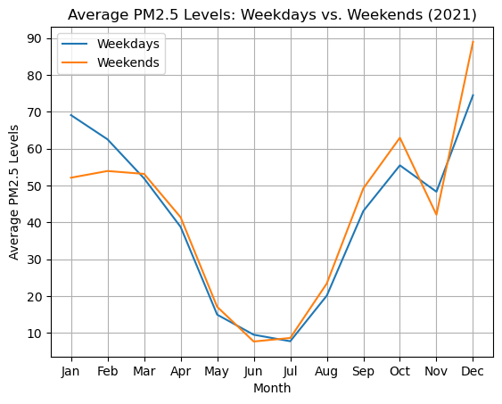

```python
req_data = apdata[(apdata['Timestamp'].dt.year == 2021) & (apdata['station'] == 'Lal Bahadur Shastri Nagar, Kalaburagi - KSPCB')]
def is_weekend(date):
    return date.weekday() >= 5
monthly_avg = req_data.groupby([req_data['Timestamp'].dt.month, req_data['Timestamp'].apply(is_weekend)])['PM2.5'].mean().unstack()
monthly_avg = monthly_avg.interpolate(method='pchip')   #Piece wise Cubic Hermite Interpolating Polynomial
#Applied cubic polynomial imputation considering that the avg pollution levels in adjacent months could be relatable and thus can be imputed by polynomials
plt.plot(monthly_avg.index, monthly_avg[False], label='Weekdays')
plt.plot(monthly_avg.index, monthly_avg[True], label='Weekends')
plt.title('Average PM2.5 Levels: Weekdays vs. Weekends (2021)')
plt.xlabel('Month')
plt.ylabel('Average PM2.5 Levels')
plt.xticks(np.arange(1, 13), ['Jan', 'Feb', 'Mar', 'Apr', 'May', 'Jun', 'Jul', 'Aug', 'Sep', 'Oct', 'Nov', 'Dec'])
plt.legend()
plt.grid(True)
plt.show()
```

***Spatio-temporal aggregation***

***1. For each state, calculate the percentage increase or decrease in PM2.5 levels during monsoon months (June to September) compared to summer months (March to May). Which state has the most difference (increase or decrease) for the year 2022?***

```python
req_data = apdata[apdata['Timestamp'].dt.year == 2022]
avgpm25_monsoon = req_data[req_data['Timestamp'].dt.month.isin([6, 7, 8, 9])].groupby('state')['PM2.5'].mean()
avgpm25_summer = req_data[req_data['Timestamp'].dt.month.isin([3, 4, 5])].groupby('state')['PM2.5'].mean()
percent_change = (np.abs(avgpm25_monsoon - avgpm25_summer) / avgpm25_summer) * 100
percent_change
print('State with most difference in PM2.5 levels during monsoon months and summer months is', percent_change.idxmax(), "with a percentage change of", percent_change[percent_change.idxmax()])
```

```
State with most difference in PM2.5 levels during monsoon months and summer months is Assam with a percentage change of 61.17641855538734
```

***2. Plot the average PM2.5 levels for Delhi across each season (Winter: December-February, Summer: March-May, Monsoon: June-September) from 2017 to 2023. What seasonal variation, if any, can you observe in pollution levels?***

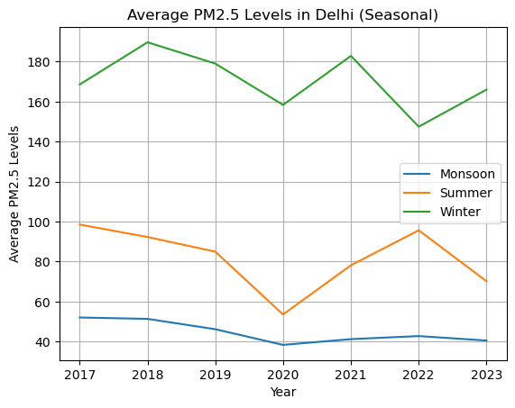

```python
req_data = apdata[(apdata['city'] == 'Delhi') & (apdata['Timestamp'].dt.year >= 2017) & (apdata['Timestamp'].dt.year <= 2023)]
avgpm25_monsoon = req_data[req_data['Timestamp'].dt.month.isin([6, 7, 8, 9])].groupby(pd.Grouper(key='Timestamp', freq='YS'))['PM2.5'].mean()
avgpm25_summer = req_data[req_data['Timestamp'].dt.month.isin([3, 4, 5])].groupby(pd.Grouper(key='Timestamp', freq='YS'))['PM2.5'].mean()
avgpm25_winter = req_data[req_data['Timestamp'].dt.month.isin([12, 1, 2])].groupby(pd.Grouper(key='Timestamp', freq='YS'))['PM2.5'].mean()
plt.plot(avgpm25_monsoon.index, avgpm25_monsoon, label='Monsoon')
plt.plot(avgpm25_summer.index, avgpm25_summer, label='Summer')
plt.plot(avgpm25_winter.index, avgpm25_winter, label='Winter')
plt.title('Average PM2.5 Levels in Delhi (Seasonal)')
plt.xlabel('Year')
plt.ylabel('Average PM2.5 Levels')
plt.legend()
plt.grid(True)
plt.show()
```

*It can be clearly inferred that Winter has the highest pollution, surpassing that of monsoon and summer with a large margin. Monsoon has very low pollution levels*

***3. Plot a time-series graph comparing Delhi’s PM2.5 levels with Mumbai’s from 2015 to 2023. Which city had more fluctuations? (Hint: Think what fluctuation means)***

*We don't have any data for the year 2015 and 2016*

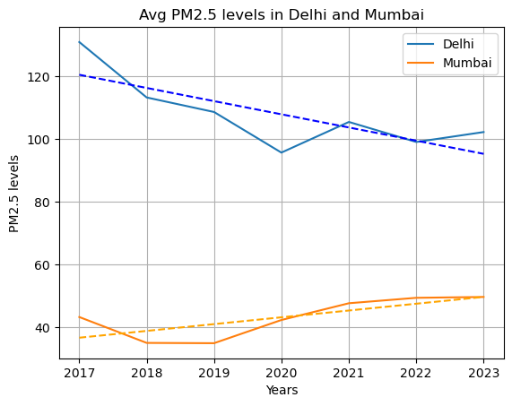

```python
#Avg PM2.5 plots
del_pol = apdata[(apdata['city'] == 'Delhi') & (apdata['Timestamp'].dt.year >= 2017) & (apdata['Timestamp'].dt.year <= 2023)].groupby(pd.Grouper(key = 'Timestamp', freq = 'YS'))['PM2.5'].mean()
mum_pol = apdata[(apdata['city'] == 'Mumbai') & (apdata['Timestamp'].dt.year >= 2017) & (apdata['Timestamp'].dt.year <= 2023)].groupby(pd.Grouper(key = 'Timestamp', freq = 'YS'))['PM2.5'].mean()
plt.plot(del_pol.index, del_pol, label = 'Delhi')
plt.plot(mum_pol.index, mum_pol, label = 'Mumbai')
plt.xlabel('Years')
plt.ylabel('PM2.5 levels')
plt.title('Avg PM2.5 levels in Delhi and Mumbai')
plt.legend()
plt.grid(True)

#linear regression lines to compare fluctuations
xd = np.arange(len(del_pol))
yd = del_pol
md, cd = np.polyfit(xd, yd, 1)
regression_lined = md * xd + cd
plt.plot(del_pol.index, regression_lined, linestyle='--', color='blue')
xm = np.arange(len(mum_pol))
ym = mum_pol
mm, cm = np.polyfit(xm, ym, 1)
regression_linem = mm * xm + cm
plt.plot(mum_pol.index, regression_linem, linestyle='--', color='orange')

plt.show()
```

*After plotting the linear regression graph, it is evident that Delhi has more fluctuations than Mumbai as the distance of the points from the linear regression is greater for Delhi, this can also be backed up by the fact that the graph of Mumbai changes its concavity at only 1 point whereas that of Delhi does so at 4 points.*

***Population-Based***

***1. Which state in India has the highest number of monitoring stations relative to its population?***

```python
station_pop = pd.merge(popdata, apdata.groupby('state')['station'].count(), on = 'state')
print(station_pop.iloc[(station_pop['station'] / station_pop['Population']).idxmax()]['state'], "has the highest number of monitoring staions relative to its population")
```

```
Chandigarh has the highest number of monitoring staions relative to its population
```

***2. Plot a bar chart showing the top 5 most polluted states in terms of per capita PM2.5 exposure in 2023.***

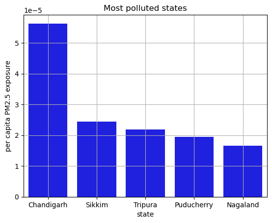

```python
req_data = apdata[apdata['Timestamp'].dt.year == 2023]
pol_states = pd.merge(req_data.groupby('state')['PM2.5'].mean(), popdata, on = 'state')
pol_states['per capita PM2.5 exposure'] = pol_states['PM2.5'] / pol_states['Population']
top_five = pol_states.nlargest(5, 'per capita PM2.5 exposure')
sns.barplot(x = top_five['state'], y = top_five['per capita PM2.5 exposure'], color = 'blue')
plt.grid(True)
plt.title('Most polluted states')
plt.show()
```

***3. Plot the relationship between population density and average PM2.5 concentration for each state. What conclusion can you draw about the correlation between population density and pollution?***

*X-axis: Population density (people per square kilometer).*

*Y-axis: Average PM2.5 concentration.*

*Use a scatter plot to show the relationship, where each point represents a state.*

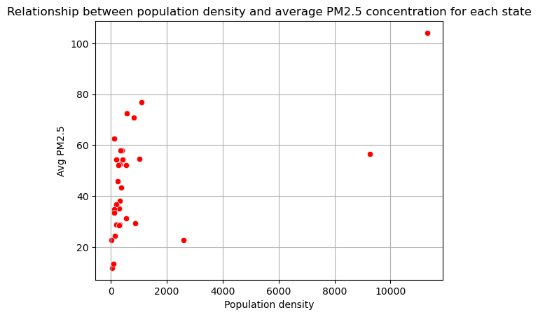

```python
req_data = pd.merge(popdata, apdata.groupby('state')['PM2.5'].mean(), on = 'state')
sns.scatterplot(x = (req_data['Population']/req_data['area']), y = req_data['PM2.5'], color = 'r')
plt.xlabel('Population density')
plt.ylabel('Avg PM2.5')
plt.title("Relationship between population density and average PM2.5 concentration for each state")
plt.grid(True)
plt.show()
```

*Most of the states share common charectristics influencing both population density and pollution....population tends to be less than 1000 for most of the states, with a avg PM2.5 level between 20 to 80. Though there are some outliers, one state having a PM2.5 level of above 100 with a population density of more than 10000 and another having population density near 9000 with PM2.5 level around 60.*

***Area Based***

***1. Which state has the highest PM2.5 concentration per square kilometer? Plot the pollution levels for all states relative to their area.***

*X-axis: States*

*Y-axis: PM2.5 concentration per square kilometer*

*Use a bar plot where each bar represents a state, and the height shows PM2.5 per sq km*

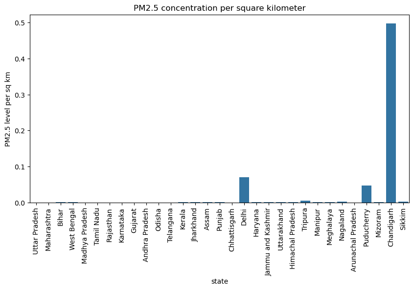

```python
req_data = pd.merge(popdata, apdata.groupby('state')['PM2.5'].mean(), on = 'state')
plt.figure(figsize = (10, 5))
sns.barplot(x = req_data['state'], y = (req_data['PM2.5']/req_data['area']))
plt.xticks(rotation = 90)
plt.ylabel('PM2.5 level per sq km')
plt.title('PM2.5 concentration per square kilometer')
plt.show()
```

*Clearly Chandigarh has the highest PM2.5 concentration level per sq km.* *Though it seems Chandigarh is highly polluted compared to other states, it should be taken into notice that the unit of the graph itself does not make sense. PM2.5 is already in units ug/m3, so dividing it by area is pointless and could lead to wrong inferences. Chandigarh has comparatively very less area but PM2.5 conc level comparable to others. This is the reason for such high value of PM2.5 conc per sqkm.*

***2. Compare the total number of monitoring stations per square kilometer in each state. Identify the state with the highest density of monitoring stations relative to its area. Show a bar plot where each bar represents a state, and the height shows the number of monitoring stations per square kilometer.***

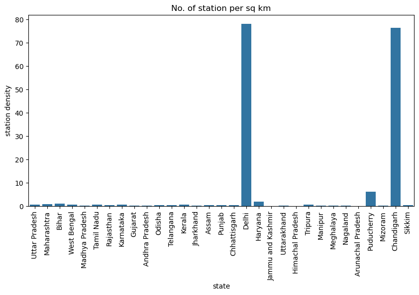

```python
req_data = pd.merge(popdata, apdata.groupby('state')['station'].count(), on = 'state')
req_data['station density'] = req_data['station'] / req_data['area']
plt.figure(figsize = (10, 5))
sns.barplot(data = req_data, x = 'state', y = 'station density')
plt.xticks(rotation = 90)
plt.title('No. of station per sq km')
plt.show()
```

*Delhi has the highest station density, closely followed by Chandigarh*

***3. Compare the average PM2.5 levels between Maharashtra and Madhya Pradesh over the year 2021. Given that both states have similar area sizes but different population densities, analyze how population density impacts pollution levels in these two states.***

```python
mah_avg = apdata[(apdata['Timestamp'].dt.year == 2021) & (apdata['state'] == 'Maharashtra')]['PM2.5'].mean()
mp_avg = apdata[(apdata['Timestamp'].dt.year == 2021) & (apdata['state'] == 'Madhya Pradesh')]['PM2.5'].mean()
mah_popdens = popdata[popdata['state'] == 'Maharashtra']['Population'].values[0] / popdata[popdata['state'] == 'Maharashtra']['area'].values[0]
mp_popdens = popdata[popdata['state'] == 'Madhya Pradesh']['Population'].values[0] / popdata[popdata['state'] == 'Madhya Pradesh']['area'].values[0]
print("Maharashtra has average PM2.5 value of", mah_avg, "with a population density of", mah_popdens, "in 2021")
print("Madhya Pradesh has average PM2.5 value of", mp_avg, "with a population density of", mp_popdens, "in 2021")
```

```
Maharashtra has average PM2.5 value of 46.44004417107665 with a population density of 365.1920230864474 in 2021
Madhya Pradesh has average PM2.5 value of 47.095951831498965 with a population density of 235.60855728429985 in 2021
```

*From the acquired data, it is analysed that population density affects pollution levels negatively in these two states, which is surprising and against the general notion and logic. Though Maharashtra has a much higher Population density than Madhya Pradesh, its pollution level is slightly lower than that of Madhya Pradesh. Concluding a relation between two parameters with only one comparison may lead to wrong, premature conclusions*

***Funding based***

***1. Compare the average PM2.5 levels between states that received NCAP funding and those that did not in 2021.***

```python
fundata['FY 21-22'] = fundata['FY 21-22'].replace('-',0)
funded_states_2021 = fundata[fundata['FY 21-22'] > 0]['state'].unique()
not_funded_states_2021 = fundata[fundata['FY 21-22'] == 0]['state'].unique()
NCAP_Funding_states = fundata['state'].unique()
not_funded_states_2021 = np.setdiff1d(NCAP_Funding_states, funded_states_2021)
apdata['NCAP_Funded'] = 'Non-Funded'
apdata.loc[apdata['state'].isin(funded_states_2021), 'NCAP_Funded'] = 'Funded'
avg_pm25_by_funding = apdata.groupby('NCAP_Funded')['PM2.5'].mean()
print("Average PM2.5 levels based on NCAP funding status:")
print(avg_pm25_by_funding)
```

```
Average PM2.5 levels based on NCAP funding status:
NCAP_Funded
Funded        62.227358
Non-Funded    52.650627
Name: PM2.5, dtype: float64
```

***2. Create a time series plot showing PM2.5 levels with an increment in NCAP funding for Assam. Has an increment of the financing led to noticeable improvements in air quality?***

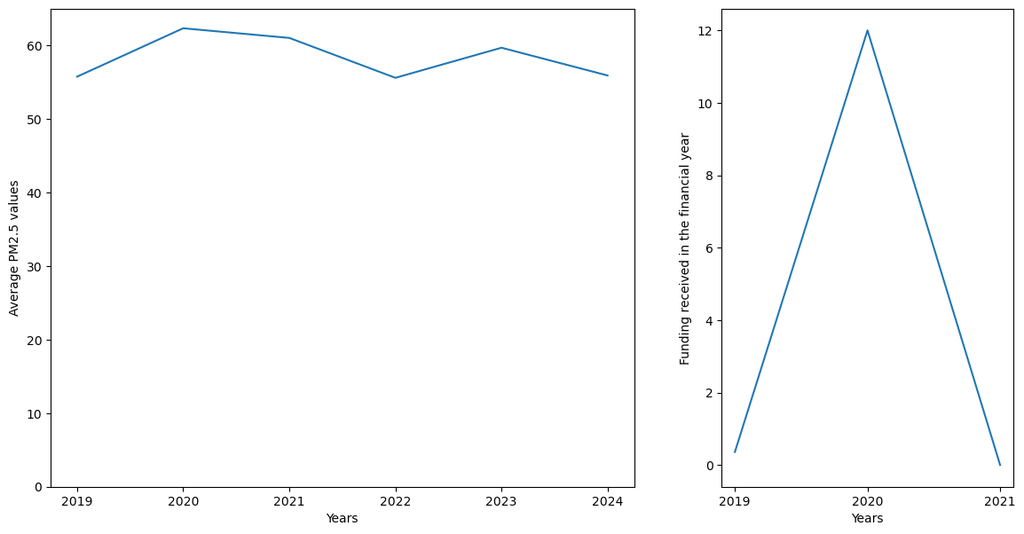

```python
import matplotlib.gridspec as gridspec
assam_pol = apdata[(apdata['state'] == 'Assam') & (apdata['Timestamp'].dt.year >= 2019)].groupby(pd.Grouper(key='Timestamp', freq='YS'))['PM2.5'].mean()
assam_funds = fundata[fundata['state'] == 'Assam'][['FY 19-20', 'FY 20-21', 'FY 21-22']].sum()
assam_pol.index = assam_pol.index.year
assam_funds.index = [2019, 2020, 2021]
fig = plt.figure(figsize=(14, 7))
gs = gridspec.GridSpec(1, 2, width_ratios=[2, 1])
ax0 = plt.subplot(gs[0])
ax0.plot(assam_pol)
ax0.set_xticks(ticks=[2019, 2020, 2021, 2022, 2023, 2024])
ax0.set_xlabel('Years')
ax0.set_ylabel('Average PM2.5 values')
ax0.set_ylim(0, 65)
ax1 = plt.subplot(gs[1])
ax1.plot(assam_funds)
ax1.set_xticks(ticks=[2019, 2020, 2021])
ax1.set_xlabel('Years')
ax1.set_ylabel('Funding received in the financial year')
plt.subplots_adjust(wspace=0.2)
plt.show()
```

*It can be observed that the pollution levels in Assam had peaked in 2020, and the same year heavy funds were allocated to Assam for air pollution control. Though there does seem to be some positive change in the pollution level, the pollution level did start decreasing, no further funds were allocatted and the pollution levels again started rising by 2023.*

***3. Create a scatter plot to showcase the area versus funding received by a state. Mark every state with a different color and show the legend outside the plot.***

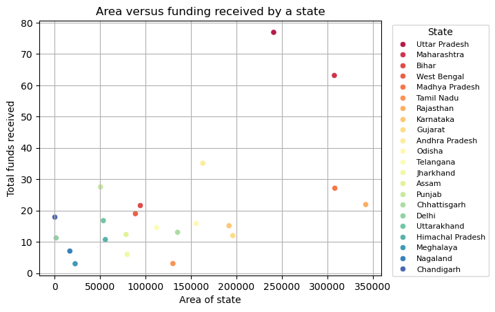

```python
req_data = pd.merge(popdata, fundata.groupby('state')['total'].sum(), on = 'state')
sns.scatterplot(data = req_data, x = 'area', y = 'total', hue = 'state', palette = 'Spectral')
plt.legend(title='State', bbox_to_anchor=(1.02, 1), fontsize = '8')
plt.grid(True)
plt.xlabel("Area of state")
plt.ylabel("Total funds received")
plt.title("Area versus funding received by a state")
plt.show()
```

***Miscellaneous Questions***

***1. For the most polluted city in 2023 (highest average pollution in 2023), calculate the percentage of days with PM2.5 levels above the hazardous threshold (300 µg/m³)***

```python
req_data = apdata[apdata['Timestamp'].dt.year == 2023]
most_pol = req_data.groupby('city')['PM2.5'].mean().idxmax()
total = req_data[(req_data['city'] == most_pol) & (req_data['PM2.5'].notnull())]['Timestamp'].count()
above_hazard = req_data[(req_data['city'] == most_pol) & (req_data['PM2.5'].notnull()) & (req_data['PM2.5'] > 300)]['Timestamp'].count()
print(most_pol, "saw", above_hazard * 100 / total, "percentage days with PM2.5 levels above the hazardous threshold.")
```

```
Darbhanga saw 23.076923076923077 percentage days with PM2.5 levels above the hazardous threshold.
```

***2. Analyze the PM2.5 levels in Delhi during Diwali (October-November) and New Year compared to regular months over the 3 years (2018-2020). Do you observe any significant pollution spikes during these festivals? If spikes are observed, Can you mark these spikes using arrows?***

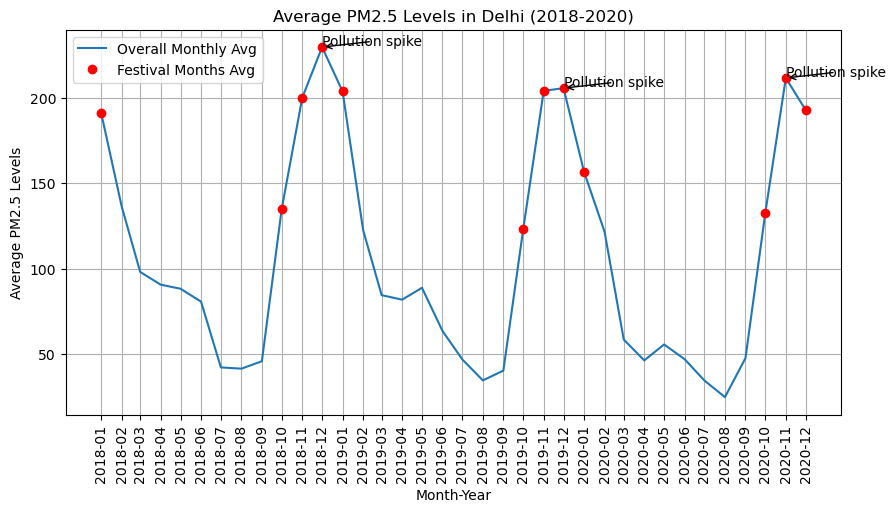

```python
from scipy.signal import find_peaks
req_data = apdata[(apdata['city'] == 'Delhi') & (apdata['Timestamp'].dt.year <= 2020) & (apdata['Timestamp'].dt.year >= 2018)]
monthly_avg_pm25 = req_data.groupby(req_data['Timestamp'].dt.to_period('M'))['PM2.5'].mean()
monthly_avg_pm25.index = monthly_avg_pm25.index.to_timestamp()
peaks, _ = find_peaks(monthly_avg_pm25.values)
plt.figure(figsize=(10, 5))
plt.plot(monthly_avg_pm25.index, monthly_avg_pm25.values, label='Overall Monthly Avg')
for peak in peaks:
    if monthly_avg_pm25.values[peak] >= 200:
        plt.annotate('Pollution spike', xy=(monthly_avg_pm25.index[peak], monthly_avg_pm25.values[peak]), xytext=(monthly_avg_pm25.index[peak], monthly_avg_pm25.values[peak]+1), arrowprops=dict(arrowstyle = '->', facecolor='red'))
monthly_avg_pm25_festiv = req_data[req_data['Timestamp'].dt.month.isin([10, 11, 12, 1])].groupby(req_data['Timestamp'].dt.to_period('M'))['PM2.5'].mean()
monthly_avg_pm25_festiv.index = monthly_avg_pm25_festiv.index.to_timestamp()
plt.plot(monthly_avg_pm25_festiv.index, monthly_avg_pm25_festiv.values, 'ro', label='Festival Months Avg')  # 'ro' for red circles
plt.xticks(monthly_avg_pm25.index, [date.strftime('%Y-%m') for date in monthly_avg_pm25.index], rotation=90)
plt.xlabel('Month-Year')
plt.ylabel('Average PM2.5 Levels')
plt.title('Average PM2.5 Levels in Delhi (2018-2020)')
plt.legend()
plt.grid(True)
plt.show()
```

***3. Identify the state that received the highest NCAP funding in 2020 and determine if its air pollution levels improved significantly by 2023. Use a line graph to compare yearly average PM2.5 trends.***

```python
fundata.groupby('state')['FY 20-21'].sum().idxmax()
```

```
'Andhra Pradesh'
```

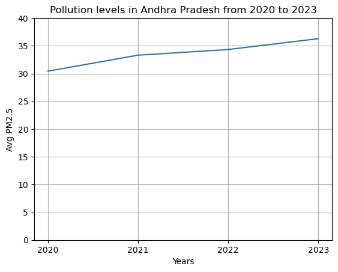

```python
plot_data = apdata[(apdata['state'] == 'Andhra Pradesh') & (apdata['Timestamp'].dt.year >= 2020) & (apdata['Timestamp'].dt.year <= 2023)].groupby(apdata['Timestamp'].dt.year)['PM2.5'].mean()
plt.plot(plot_data)
plt.ylim(0, 40)
plt.xticks(ticks = [2020, 2021, 2022, 2023])
plt.grid(True)
plt.ylabel('Avg PM2.5')
plt.xlabel('Years')
plt.title('Pollution levels in Andhra Pradesh from 2020 to 2023')
plt.show()
```

*Instead of improving, the pollution levels have slowly degraded in Andhra Pradesh, despite the fact that it received highest NCAP funding in 2020. The Avg PM2.5 level is increasing over the years.*

***4. Draw the map of India and plot the sensor locations on the map.***

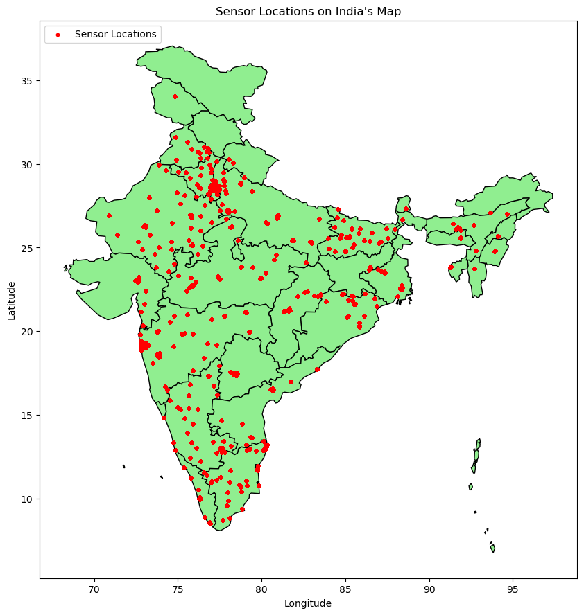

```python
import geopandas as gpd
india_map = gpd.read_file(r"C:\Users\ujass\Downloads\india-polygon.shp")
req_data = apdata[apdata['latitude'].notnull()]
gdf_sensors = gpd.GeoDataFrame(req_data, geometry=gpd.points_from_xy(req_data["longitude"], req_data["latitude"]))
gdf_sensors.set_crs(india_map.crs, inplace=True)
fig, ax = plt.subplots(figsize=(10, 12))
india_map.plot(ax=ax, color="lightgreen", edgecolor="black")
gdf_sensors.plot(ax=ax, color="red", markersize=10, label="Sensor Locations")
plt.legend()
plt.title("Sensor Locations on India's Map")
plt.xlabel("Longitude")
plt.ylabel("Latitude")
plt.legend(loc='upper left')
plt.show()
```

***Tell us something interesting from the dataset that we have not asked. Anything that intrigues you, anything that might be useful to the policymakers.***

*One thing that we found to be very strange was that considering we are analysing this data to help policymakers make policies to check pollution levels, we have only 728348 rows with non-null values in PM2.5, the primary parameter to analyse pollution levels, out of a total of 1627461 rows. About 55.25% of rows do not have a value for the PM2.5 column. For the PM10 column, 57.05% of rows have null values. Thus, we don't have data for more than 50 % of stations that is to be used to analyse their pollution level. The results we gain from this data, or the policy made upon this, might be skewed or irrelevant. The locations whose station data is available might benefit from these inferences. Locations of some stations are also not available. So, the data might be impactful in small clusters, but for implementing nationwide policies, it is not sufficient and can't be relied upon. Thus, it is necessary for policymakers to first get enough data to analyse. Hence, if pollution levels are available for analysis for a maximum of the stations, only then can they introduce policies that can check the alarming pollution levels across the country.*

```python
apdata.info()
```

```
<class 'pandas.core.frame.DataFrame'>
RangeIndex: 1627461 entries, 0 to 1627460
Data columns (total 10 columns):
 #   Column       Non-Null Count    Dtype
---  ------       --------------    -----
 0   Timestamp    1627461 non-null  datetime64[ns]
 1   station      1627461 non-null  object
 2   PM2.5        728348 non-null   float64
 3   PM10         699014 non-null   float64
 4   address      1387431 non-null  object
 5   city         1563702 non-null  object
 6   latitude     1563702 non-null  float64
 7   longitude    1563702 non-null  float64
 8   state        1563702 non-null  object
 9   NCAP_Funded  1627461 non-null  object
dtypes: datetime64[ns](1), float64(4), object(5)
memory usage: 124.2+ MB
```